# Assignment01_result

## 벨라소-비지네르 비닉 기법 해독

**해독 과정 요약:**

1. **암호문 준비**: 해독할 암호문을 계산하기 편한 형태로 가공합니다.
2. **비닉용 건 찾기**: 벨라소-비지네르 비닉 기법의 복호용 건을 찾습니다.
3. **암호문 복호화**: 복호화 함수를 사용하여 암호문을 복호화합니다.
4. **복호화 결과 가공**: 다자 환자식 비닉 기법에 맞춰 복호화된 메시지와 암호문의 각 글자가 각각 대응되어 한 눈에 보기 편하도록 가공합니다.

### 1. 암호문 준비

먼저 분석할 암호문을 설정하고 특수 문자 및 공백을 제거하여 분석하기 쉬운 형태로 만듭니다.

```python
Encrypted_Original = """
DPXWGKZRHDKGHNLQOBKJSATUMYSHYRRMPKGDQGZQPZHFRRMWNRMPETLQCTZCNQTKW
UMIMZIIGGCPZTGIGPBECCPXPYCQGAGNQGZDYZMPMIMTKQGQMAFOZYTKSTRWSBQGZR
RMGTXSWVVSZIMBMXWYMFOVXMFOZETLNATGLOVTFCNPXKBSIKRISBMRZOKTNQOQGAC
BATYCRIOXLPZHFRRMGTXSATGLOPTLLYZXTJPZBXLNALHQRMFNQDUTDCSUTZGXIKRM
XMLTLXMATBKDXKWMTHLCBMETRSWGLFSXPBRRPXKDKBAXPVIVDMPLTNERBXKJITHOC
PWKACBUHMFOZTGBKLFBPKBBHLPWKACBABLROZLBLDMEEGQMGVCKVWLUOMMGYDCKX"""

Encrypted = Encrypted_Original.replace("\n", "").replace(" ", "")
print("Processed Encrypted Text:")
print(Encrypted)
```

```
Processed Encrypted Text:
DPXWGKZRHDKGHNLQOBKJSATUMYSHYRRMPKGDQGZQPZHFRRMWNRMPETLQCTZC…
```

### 2. 비닉용 건 찾기

암호문의 빈도 분석 및 반복되는 문자열 분석을 통해 암호문의 특성을 파악합니다. 이는 비닉용 건의 길이를 추정하는 데 도움이 됩니다.

#### 2.1. 반복 문자열 분석 및 비닉용 건 길이 추정

암호문에서 반복되는 문자열을 찾아 그 간격의 최대공약수(GCD)를 계산하여 비닉용 건의 길이를 추정합니다.

```python
from collections import defaultdict
import math

repeating_sequences_3plus = defaultdict(list)
min_length = 3 # Changed minimum length to 3

for length in range(min_length, len(Encrypted) // 2):
    for i in range(len(Encrypted) - length + 1):
        sequence = Encrypted[i : i + length]
        # Check if the sequence appears more than once
        if Encrypted.count(sequence) > 1:
            # Find all occurrences of the sequence
            start = -1
            while True:
                start = Encrypted.find(sequence, start + 1)
                if start == -1:
                    break
                if start not in repeating_sequences_3plus[sequence]:
                  repeating_sequences_3plus[sequence].append(start)

# Sort repeating sequences by frequency (number of occurrences) in descending order
sorted_repeating_sequences_3plus = sorted(repeating_sequences_3plus.items(), key=lambda item: len(item[1]), reverse=True)

# Calculate and print the intervals for each repeating sequence relative to the first occurrence
print("Repeating sequences (3+ characters) sorted by frequency:")
for sequence, positions in sorted_repeating_sequences_3plus:
    count = len(positions)
    if count > 1: # Only show sequences that repeat at least once after the first occurrence
      first_occurrence = positions[0]
      intervals_from_first = [pos - first_occurrence for pos in positions[1:]]
      print(f"Sequence: {sequence}, Count: {count}, Positions: {positions}, Intervals from first: {intervals_from_first}")
    else:
      pass # Skipping sequences that only appear once for brevity as intervals are the focus

# Get the sequence with the highest count from the sorted list
if sorted_repeating_sequences_3plus:
    most_frequent_sequence_info = sorted_repeating_sequences_3plus[0]
    sequence = most_frequent_sequence_info[0]
    positions = most_frequent_sequence_info[1]

    # Calculate the intervals from the first occurrence
    if len(positions) > 1:
        first_occurrence = positions[0]
        intervals_from_first = [pos - first_occurrence for pos in positions[1:]]

        # Calculate the GCD of the intervals
        if intervals_from_first:
            gcd_value = intervals_from_first[0]
            for i in range(1, len(intervals_from_first)):
                gcd_value = math.gcd(gcd_value, intervals_from_first[i])
            print(f"\nThe sequence with the highest count is '{sequence}' with intervals {intervals_from_first}.")
            print(f"The GCD of these intervals (potential key length) is: {gcd_value}")
            key_length = gcd_value # Set key_length based on GCD
        else:
            print(f"\nThe sequence '{sequence}' has no intervals to calculate GCD from.")
            key_length = 1 # Default to 1 if no intervals
    else:
        print(f"\nThe sequence '{sequence}' does not repeat enough times to have intervals.")
        key_length = 1 # Default to 1 if not enough repeats
else:
    print("\nNo repeating sequences of length 3 or more found.")
    key_length = 1 # Default to 1 if no repeating sequences

print(f"\nEstimated key length: {key_length}")
```

```
Repeating sequences (3+ characters) sorted by frequency:
Sequence: RRM, Count: 4, Positions: [29, 44, 129, 209], Intervals from first: [15, 100, 180]
Sequence: QGZ, Count: 3, Positions: [36, 96, 126], Intervals from first: [60, 90]
Sequence: FOZ, Count: 3, Positions: [114, 154, 334], Intervals from first: [40, 220]
Sequence: MFO, Count: 3, Positions: [148, 153, 333], Intervals from first: [5, 185]
Sequence: ACB, Count: 3, Positions: [193, 328, 353], Intervals from first: [135, 160]
Sequence: SAT, Count: 2, Positions: [20, 215], Intervals from first: [195]
Sequence: RMP, Count: 2, Positions: [30, 49], Intervals from first: [19]
Sequence: PZH, Count: 2, Positions: [40, 205], Intervals from first: [165]
Sequence: ZHF, Count: 2, Positions: [41, 206], Intervals from first: [165]
Sequence: HFR, Count: 2, Positions: [42, 207], Intervals from first: [165]
Sequence: FRR, Count: 2, Positions: [43, 208], Intervals from first: [165]
Sequence: ETL, Count: 2, Positions: [52, 157], Intervals from first: [105]
Sequence: MIM, Count: 2, Positions: [66, 104], Intervals from first: [38]
Sequence: ZTG, Count: 2, Positions: [76, 336], Intervals from first: [260]
Sequence: QGA, Count: 2, Positions: [91, 191], Intervals from first: [100]
Sequence: GQM, Count: 2, Positions: [110, 369], Intervals from first: [259]
Sequence: RMG, Count: 2, Positions: [130, 210], Intervals from first: [80]
Sequence: MGT, Count: 2, Positions: [131, 211], Intervals from first: [80]
Sequence: GTX, Count: 2, Positions: [132, 212], Intervals from first: [80]
Sequence: TXS, Count: 2, Positions: [133, 213], Intervals from first: [80]
Sequence: LNA, Count: 2, Positions: [159, 234], Intervals from first: [75]
Sequence: ATG, Count: 2, Positions: [161, 216], Intervals from first: [55]
Sequence: TGL, Count: 2, Positions: [162, 217], Intervals from first: [55]
Sequence: GLO, Count: 2, Positions: [163, 218], Intervals from first: [55]
Sequence: PXK, Count: 2, Positions: [171, 296], Intervals from first: [125]
Sequence: IKR, Count: 2, Positions: [176, 256], Intervals from first: [80]
Sequence: CBA, Count: 2, Positions: [194, 354], Intervals from first: [160]
Sequence: PWK, Count: 2, Positions: [325, 350], Intervals from first: [25]
Sequence: WKA, Count: 2, Positions: [326, 351], Intervals from first: [25]
Sequence: KAC, Count: 2, Positions: [327, 352], Intervals from first: [25]
Sequence: PZHF, Count: 2, Positions: [40, 205], Intervals from first: [165]
Sequence: ZHFR, Count: 2, Positions: [41, 206], Intervals from first: [165]
Sequence: HFRR, Count: 2, Positions: [42, 207], Intervals from first: [165]
Sequence: FRRM, Count: 2, Positions: [43, 208], Intervals from first: [165]
Sequence: RRMG, Count: 2, Positions: [129, 209], Intervals from first: [80]
Sequence: RMGT, Count: 2, Positions: [130, 210], Intervals from first: [80]
Sequence: MGTX, Count: 2, Positions: [131, 211], Intervals from first: [80]
Sequence: GTXS, Count: 2, Positions: [132, 212], Intervals from first: [80]
Sequence: MFOZ, Count: 2, Positions: [153, 333], Intervals from first: [180]
```

[output cut: 12 more lines]

```
Sequence: ATGLO, Count: 2, Positions: [161, 216], Intervals from first: [55]
Sequence: PWKAC, Count: 2, Positions: [325, 350], Intervals from first: [25]
Sequence: WKACB, Count: 2, Positions: [326, 351], Intervals from first: [25]
Sequence: PZHFRR, Count: 2, Positions: [40, 205], Intervals from first: [165]
Sequence: ZHFRRM, Count: 2, Positions: [41, 206], Intervals from first: [165]
Sequence: RRMGTX, Count: 2, Positions: [129, 209], Intervals from first: [80]
Sequence: RMGTXS, Count: 2, Positions: [130, 210], Intervals from first: [80]
Sequence: PWKACB, Count: 2, Positions: [325, 350], Intervals from first: [25]
Sequence: PZHFRRM, Count: 2, Positions: [40, 205], Intervals from first: [165]
Sequence: RRMGTXS, Count: 2, Positions: [129, 209], Intervals from first: [80]

The sequence with the highest count is 'RRM' with intervals [15, 100, 180].
The GCD of these intervals (potential key length) is: 5

Estimated key length: 5
```

#### 2.2. 추정된 비닉용 건의 길이로 암호문 분할 및 빈도 분석

추정된 비닉용 건의 길이를 바탕으로 암호문을 여러 개의 부분 문자열(substring)로 분할합니다.

```python
# Use the estimated key_length from the previous cell
if 'key_length' not in locals() or key_length <= 0:
    key_length = 5 # Default to 5 if key_length was not determined or invalid

substrings = [""] * key_length
for i, char in enumerate(Encrypted):
    substrings[i % key_length] += char

# Print the created substrings
for i, substring in enumerate(substrings):
    print(f"Substring {i+1}: {substring}")
```

```
Substring 1: DKKQSYRDPRMQNUIPGCCNYIGOSBRSZXOONONSSOOBRPRSOYPNRDSXXXKMBSSRKVPRIPBOKKPBODQKOD
Substring 2: PZGOASMQZMPCQMIZPPQQZMQZTQMWIWVZAVPIBKQAIZMAPZZAMUUIMMDTMWXPBILBTWUZLBWAZMMVMC
Substring 3: XRHBTHPGHWETTIGTBXGGMTMYRGGVMYXETTXKMTGTOHGTTXBLFTTKLAXHEGPXAVTXHKHTFBKBLEGWMK
Substring 4: WHNKUYKZFNTZKMGGEPAZPKATWZTVBMMTGFKRRNAYXFTGLTXHNDZRTTKLTLBKXDNKOAMGBHALBEVLGX
Substring 5: GDLJMRGQRRLCWZCICYGDMQFKSRXSMFFLLCBIZQCCLRXLLJLQQCGMLBWCRFRDPMEJCCFBPLCRLGCUY
```

#### 2.3. 각 Substring의 상대 빈도 분석 및 평균 계산

각 Substring에서 A부터 Z까지의 알파벳 상대 빈도를 계산하고, 각 Substring별 상대 빈도의 평균을 계산합니다.

```python
from collections import Counter

relative_frequencies = {}
alphabet = "ABCDEFGHIJKLMNOPQRSTUVWXYZ"
key_length = len(substrings)

# Calculate relative frequencies for each substring
for i, substring in enumerate(substrings):
    substring_name = f"Substring {i+1}"
    substring_length = len(substring)
    relative_frequencies[substring_name] = {}
    char_counts = Counter(substring) # Use Counter for efficient counting

    for char in alphabet:
        count = char_counts.get(char, 0) # Get count, default to 0 if char not present
        relative_frequencies[substring_name][char] = count / substring_length

    # Calculate and print the average of relative frequencies within this substring
    substring_freqs = relative_frequencies[substring_name] # Use the dictionary directly
    min_freq = min(substring_freqs.values())
    max_freq = max(substring_freqs.values())
    average_freq = sum(substring_freqs.values()) / len(alphabet)

    # Find the character(s) with min and max frequencies
    min_chars = [char for char, freq in substring_freqs.items() if freq == min_freq]
    max_chars = [char for char, freq in substring_freqs.items() if freq == max_freq]


    print(f"{substring_name} Relative Frequencies:")
    for char in alphabet:
        print(f"  {char}: {relative_frequencies[substring_name][char]:.6f}")
    print(f"Minimum Relative Frequency in {substring_name}: {min_freq:.6f} (Character(s): {', '.join(min_chars)})")
    print(f"Maximum Relative Frequency in {substring_name}: {max_freq:.6f} (Character(s): {', '.join(max_chars)})")
    print(f"Average Relative Frequency in {substring_name}: {average_freq:.6f}")
    print("-" * 30) # Separator for clarity


# Calculate the average relative frequencies across all substrings (optional, but keeping as it was in previous analysis)
average_relative_frequencies = {}
for char in alphabet:
    total_freq = 0
    for substring_name in relative_frequencies:
        total_freq += relative_frequencies[substring_name][char]
    average_relative_frequencies[char] = total_freq / key_length

# Print the average relative frequencies across all substrings, formatted to 6 decimal places
print("\nAverage Relative Frequencies Across All Substrings (for reference):")
sorted_avg_freq = sorted(average_relative_frequencies.items(), key=lambda item: item[1], reverse=True)
for char, freq in sorted_avg_freq:
    print(f"  {char}: {freq:.6f}")
```

```
Substring 1 Relative Frequencies:
  A: 0.000000
  B: 0.064103
  C: 0.025641
  D: 0.064103
  E: 0.000000
  F: 0.000000
  G: 0.025641
  H: 0.000000
  I: 0.038462
  J: 0.000000
  K: 0.089744
  L: 0.000000
  M: 0.025641
  N: 0.064103
  O: 0.128205
  P: 0.089744
  Q: 0.038462
  R: 0.102564
  S: 0.115385
  T: 0.000000
  U: 0.012821
  V: 0.012821
  W: 0.000000
  X: 0.051282
  Y: 0.038462
  Z: 0.012821
Minimum Relative Frequency in Substring 1: 0.000000 (Character(s): A, E, F, H, J, L, T, W)
Maximum Relative Frequency in Substring 1: 0.128205 (Character(s): O)
Average Relative Frequency in Substring 1: 0.038462
------------------------------
Substring 2 Relative Frequencies:
  A: 0.076923
  B: 0.051282
  C: 0.025641
  D: 0.012821
  E: 0.000000
  F: 0.000000
  G: 0.012821
  H: 0.000000
```

[output cut: 128 more lines]

```
  Q: 0.038628
  O: 0.033333
  A: 0.033333
  I: 0.030836
  S: 0.030836
  D: 0.028305
  W: 0.028272
  F: 0.025808
  H: 0.025641
  N: 0.025641
  Y: 0.023144
  V: 0.020513
  E: 0.017982
  U: 0.015418
  J: 0.007792
```

#### 2.4. 영문의 낱자의 출현 상대 빈도

sample_text의 영문 낱자의 출현 상대 빈도를 계산하여 그래프로 나타냅니다.

복호문의 영문 낱자의 출현 빈도가 sample_text의 영문 낱자의 출현 빈도와 유사할 것이라 추측할 수 있습니다.

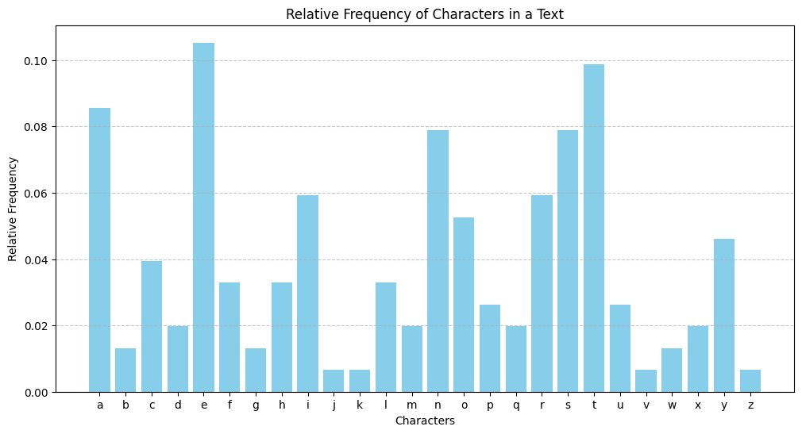

```python
import matplotlib.pyplot as plt
from collections import Counter

def plot_relative_frequency(text):
    """
    Calculates and plots the relative frequency of letters in a given text.

    Args:
        text (str): The input text to analyze.
    """
    # Convert the text to lowercase and filter out non-alphabetic characters
    cleaned_text = ''.join(filter(str.isalpha, text.lower()))

    if not cleaned_text:
        print("Error: No alphabetic characters found in the text.")
        return

    # Count the frequency of each character
    char_counts = Counter(cleaned_text)

    # Calculate the total number of characters
    total_chars = len(cleaned_text)

    # Calculate the relative frequency of each character
    relative_frequencies = {char: count / total_chars for char, count in char_counts.items()}

    # Sort the frequencies alphabetically for consistent plotting
    sorted_freqs = sorted(relative_frequencies.items())
    chars, freqs = zip(*sorted_freqs)

    # Create the bar chart
    plt.figure(figsize=(12, 6))
    plt.bar(chars, freqs, color='skyblue')

    # Add labels and a title
    plt.title('Relative Frequency of Characters in a Text')
    plt.xlabel('Characters')
    plt.ylabel('Relative Frequency')
    plt.grid(axis='y', linestyle='--', alpha=0.7)

    # Display the plot
    plt.show()

# --- Example Usage ---

# You can replace this with your own text or a passage from a book.
sample_text = """
The quick brown fox jumps over the lazy dog.
This is an example text to demonstrate character frequency analysis.
Cryptanalysis often begins with frequency analysis to find patterns.
"""

# Call the function with the sample text
plot_relative_frequency(sample_text)
```

#### 2.5. Substring별 상대 빈도 그래프 시각화

각 Substring의 영문의 낱자의 상대 빈도를 그래프로 시각화하여 빈도 분포의 특징을 파악하고, 특정 문자를 다른 색으로 강조하여 비닉용 건 추정을 돕습니다.

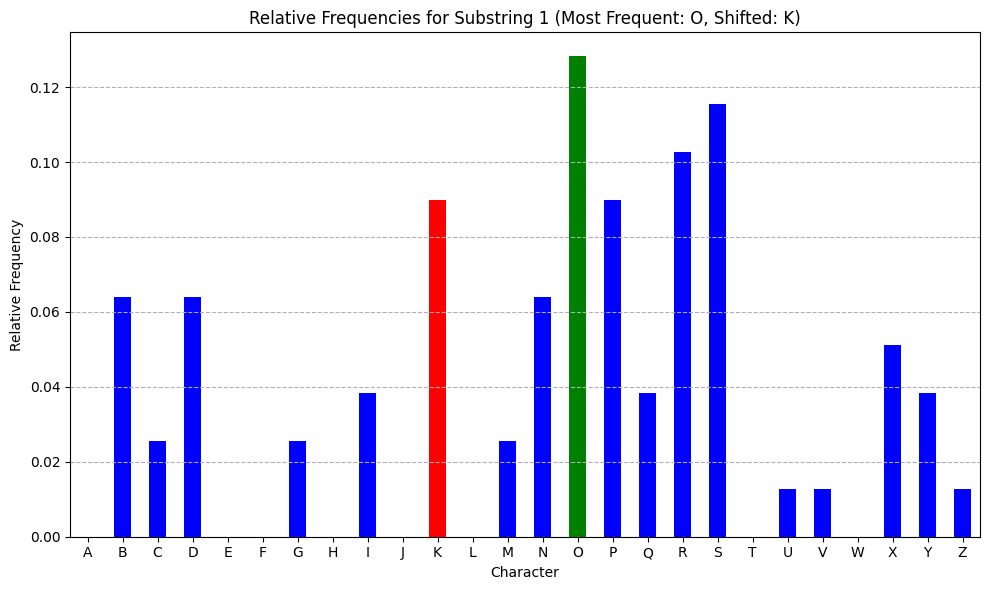

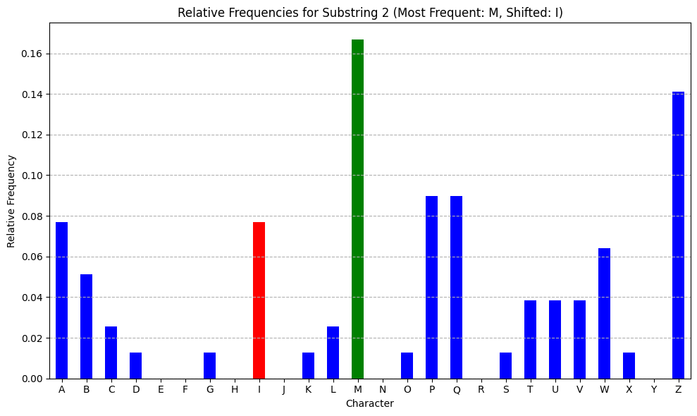

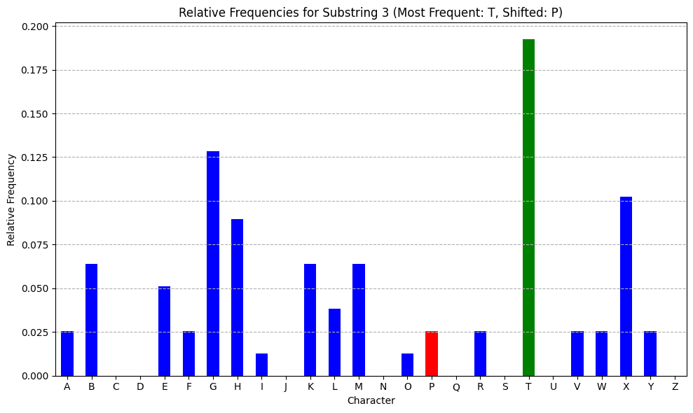

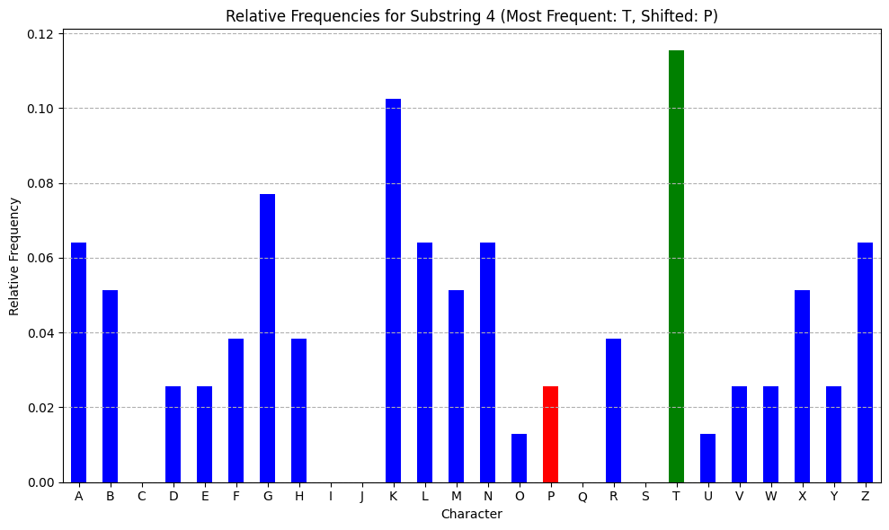

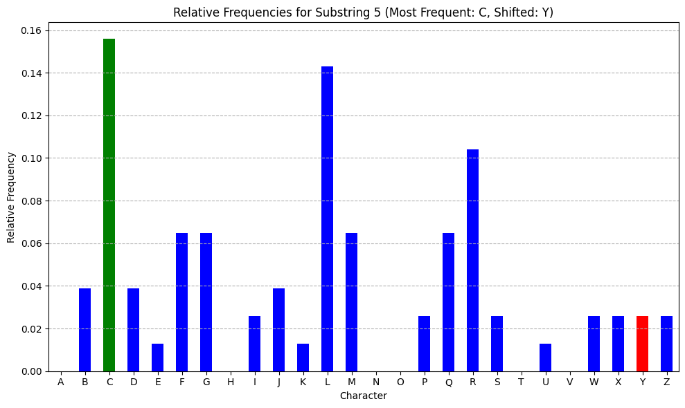

```python
import matplotlib.pyplot as plt
import pandas as pd
from collections import Counter

# Assuming relative_frequencies dictionary is available from previous steps
# And substrings are ordered: Substring 1, Substring 2, ... Substring 5
alphabet = "ABCDEFGHIJKLMNOPQRSTUVWXYZ"

# Plotting relative frequencies for each substring
for i, (substring_name, freqs) in enumerate(relative_frequencies.items()):
    # Convert dictionary to pandas Series for easier plotting
    freq_series = pd.Series(freqs)

    # Sort by character for consistent plotting order
    freq_series = freq_series.sort_index()

    # Find the character with the highest frequency in the current substring
    most_frequent_char = freq_series.idxmax()

    # Calculate the character 4 positions before the most frequent character
    most_frequent_index = alphabet.index(most_frequent_char)
    shifted_char_index = (most_frequent_index - 4) % 26
    shifted_char = alphabet[shifted_char_index]

    plt.figure(figsize=(10, 6))
    # Create a list of colors, default blue, green for the most frequent, and red for the shifted character
    colors = []
    for char in freq_series.index:
        if char == most_frequent_char:
            colors.append('green') # Highlight most frequent in green
        elif char == shifted_char:
            colors.append('red') # Highlight shifted character in red
        else:
            colors.append('blue') # Default color

    freq_series.plot(kind='bar', color=colors)
    plt.title(f'Relative Frequencies for {substring_name} (Most Frequent: {most_frequent_char}, Shifted: {shifted_char})')
    plt.xlabel('Character')
    plt.ylabel('Relative Frequency')
    plt.xticks(rotation=0)
    plt.grid(axis='y', linestyle='--')
    plt.tight_layout()
    plt.show()
```

### 2.6. Chi-squared 테스트를 통한 비닉용 건 추정

각 Substring의 빈도 분포와 영어 평문의 빈도 분포를 비교하는 Chi-squared 테스트를 사용하여 각 Substring에 적용된 시프트 값을 추정하고, 이를 통해 최종 암호용 건을 추정합니다.

## 코드 설명: Chi-squared 테스트를 통한 비닉용 건 추정

이 코드는 이전 단계에서 추정된 비닉용 건의 길이를 사용하여 각 substring에 대한 Chi-squared 테스트를 수행하고, 이를 통해 벨라소-비지네르 비닉 기법의 각 비닉용 건 문자를 추정합니다.

**주요 기능:**

1. **영어 문자 빈도 설정**: 일반적인 영어 텍스트의 알파벳 문자 상대 빈도 데이터를 `english_freq` 딕셔너리에 저장합니다. 이 데이터는 Chi-squared 테스트의 '기대값'으로 사용됩니다.
2. **Chi-squared 테스트 수행**:
   - 추정된 `key_length`를 기반으로 각 substring에 대해 반복합니다.
   - 각 substring에 대해 0부터 25까지 가능한 모든 시프트 값(`shift`)을 적용하여 가상으로 시프트된 문자열을 생성합니다.
   - 시프트된 문자열의 실제 문자 빈도(`observed_counts`)를 계산합니다.
   - 각 문자에 대해 Chi-squared 통계량을 계산합니다. 이 통계량은 관찰된 빈도와 영어 평문의 기대 빈도 간의 차이를 측정합니다.

     공식은 `((관찰된 빈도 - 기대 빈도) ** 2) / 기대 빈도`입니다.
   - 가장 낮은 Chi-squared 값을 갖는 시프트 값을 해당 substring의 최적 시프트로 결정합니다. Chi-squared 값이 낮을수록 해당 시프트가 적용된 문자열의 빈도 분포가 영어 평문의 빈도 분포와 유사하다는 의미입니다.
3. **비닉용 건 문자 추정**: 각 substring의 최적 시프트 값을 바탕으로 해당하는 Vigenère 비닉용 건 문자를 추정합니다. Chi-squared 테스트에서 찾은 최적 시프트는 암호문 문자에 '더했을 때' 평문과 유사한 빈도를 보이는 시프트입니다. 벨라소-비지네르 복호화는 '빼기' 연산이므로, 실제 비닉용 건 문자는 이 시프트의 역에 해당합니다 (26 - shift) mod 26.
4. **추정 건 생성**: 추정된 각 건 문자를 합쳐서 최종적인 잠재적 암호용 건을 생성합니다.
5. **결과 출력**: 각 substring에 대한 최적 시프트와 그 때의 Chi-squared 값, 그리고 최종적으로 추정된 잠재적 건을 출력합니다.

이 코드는 통계적 방법을 사용하여 암호 분석의 핵심 단계인 비닉용 건 추정을 자동화합니다.

```python
from collections import Counter
import math

# English letter frequencies (as percentages)
english_freq = {
    'A': 8.167, 'B': 1.492, 'C': 2.782, 'D': 4.253, 'E': 12.702, 'F': 2.228,
    'G': 2.015, 'H': 6.094, 'I': 6.966, 'J': 0.153, 'K': 0.772, 'L': 4.025,
    'M': 2.406, 'N': 6.749, 'O': 7.507, 'P': 1.929, 'Q': 0.095, 'R': 5.987,
    'S': 6.327, 'T': 9.056, 'U': 2.758, 'V': 0.978, 'W': 2.360, 'X': 0.150,
    'Y': 1.974, 'Z': 0.074
}

alphabet = "ABCDEFGHIJKLMNOPQRSTUVWXYZ"
key_length = len(substrings) # Use the actual key length from the substrings

estimated_shifts = {}

print(f"Performing Chi-squared test for each substring (key length {key_length}):")

for i in range(key_length):
    substring = substrings[i]
    substring_name = f"Substring {i+1}"
    min_chi_squared = float('inf')
    best_shift = 0

    for shift in range(26):
        shifted_substring = ""
        for char in substring:
            if char in alphabet:
                char_index = alphabet.index(char)
                shifted_index = (char_index + shift) % 26 # Apply shift
                shifted_substring += alphabet[shifted_index]
            else:
                shifted_substring += char # Keep non-alphabetic chars

        # Calculate observed frequencies for the shifted substring
        observed_counts = Counter(shifted_substring)
        substring_length = len(shifted_substring)

        # Calculate Chi-squared statistic
        chi_squared = 0
        for char in alphabet:
            observed_freq = observed_counts.get(char, 0)
            expected_freq = (english_freq.get(char, 0) / 100) * substring_length # Convert percentage to count
            # Avoid division by zero for expected_freq
            if expected_freq > 0:
                chi_squared += ((observed_freq - expected_freq) ** 2) / expected_freq
            # If expected_freq is 0 but observed is not, this contributes significantly
            elif observed_freq > 0:
                 chi_squared += observed_freq ** 2 / 0.01 # Add a small penalty, avoid inf

        # Update best shift if the current Chi-squared is lower
        if chi_squared < min_chi_squared:
            min_chi_squared = chi_squared
            best_shift = shift

    estimated_shifts[substring_name] = best_shift
    print(f"  {substring_name}: Best shift is {best_shift} (Chi-squared: {min_chi_squared:.2f})")


# Construct the potential key from the estimated shifts
# The shift found by the Chi-squared test is the amount we added to the ciphertext
# to make its frequency distribution look like English plaintext.
# To decrypt, we subtract the key. If C - K = P, then K = C - P.
# If shifting C by 's' gives P (C + s = P mod 26), then s = (P - C) mod 26.
# The shift 's' found here is the amount to ADD to the ciphertext character to get plaintext.
# The key character 'K' is the one such that C - K = P.
# So, K = (C - P) mod 26.
# If C + s = P, then s = P - C.
# K = -(P - C) = C - P.
# So K = -s mod 26, or (26 - s) mod 26.

potential_key_chars = [alphabet[(26 - shift) % 26] for shift in estimated_shifts.values()]
potential_key = "".join(potential_key_chars)

print(f"\nPotential key based on Chi-squared test: {potential_key}")
```

```
Performing Chi-squared test for each substring (key length 5):
  Substring 1: Best shift is 16 (Chi-squared: 36.40)
  Substring 2: Best shift is 18 (Chi-squared: 21.60)
  Substring 3: Best shift is 7 (Chi-squared: 26.63)
  Substring 4: Best shift is 7 (Chi-squared: 29.72)
  Substring 5: Best shift is 2 (Chi-squared: 88.69)

Potential key based on Chi-squared test: KITTY
```

## 최적 시프트 적용 후 Substring별 상대 빈도 시각화

이 셀은 Chi-squared 테스트를 통해 각 substring에 대해 추정된 최적 시프트 값을 적용한 후의 문자 상대 빈도를 그래프로 시각화합니다. 이를 통해 시프트된 문자열의 빈도 분포가 영어 평문의 빈도 분포와 얼마나 유사해졌는지 시각적으로 확인할 수 있습니다.

```
Plotting relative frequencies after applying the best shift:
```

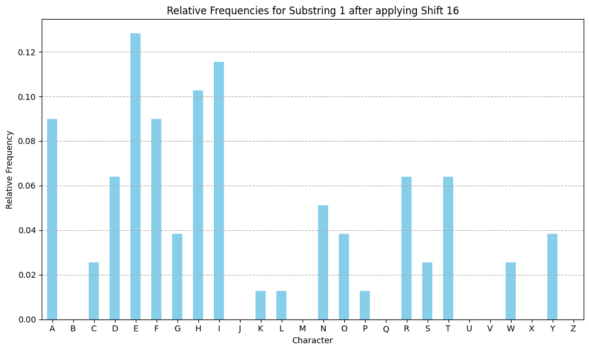

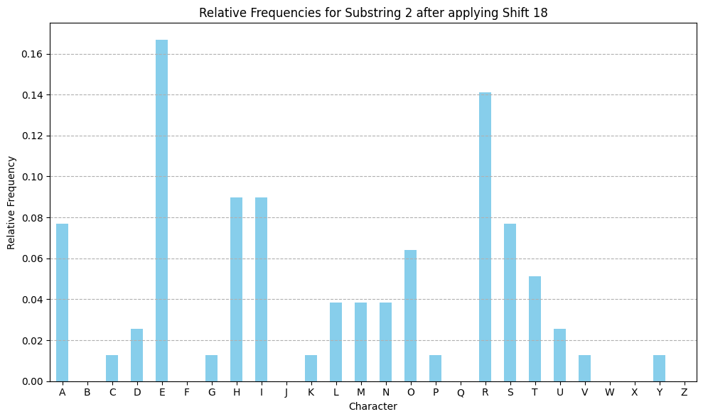

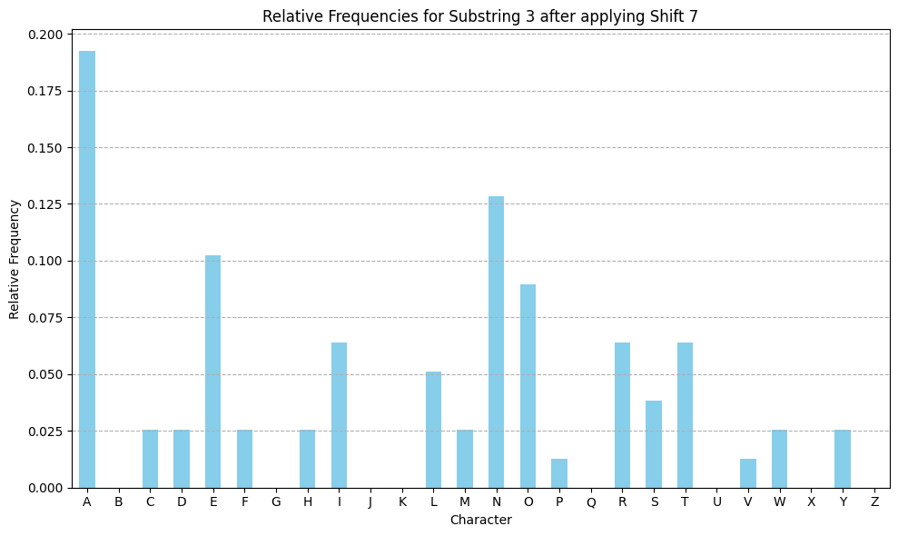

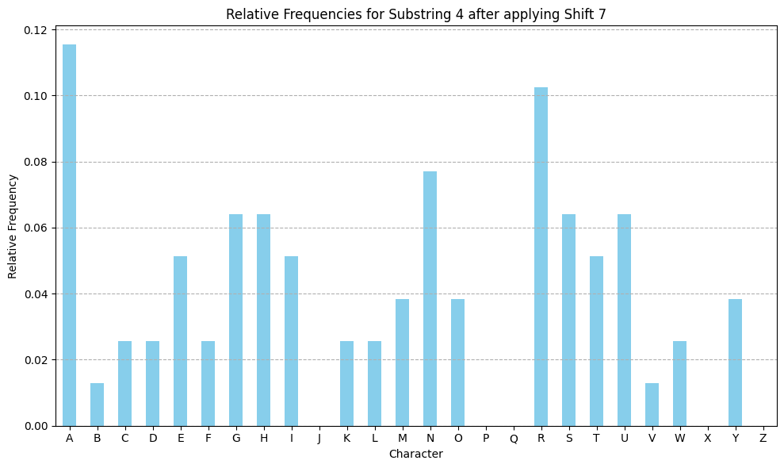

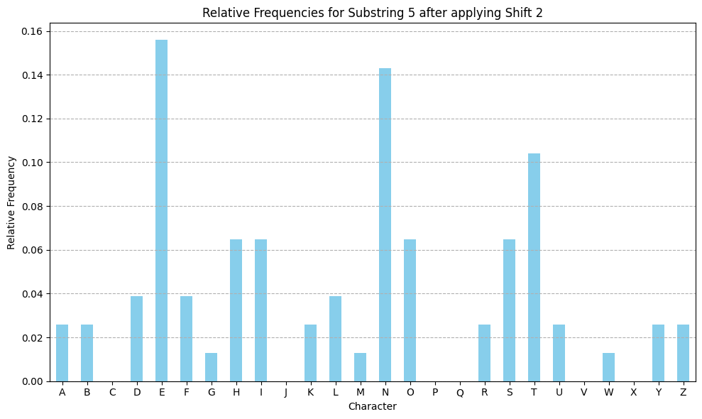

```python
import matplotlib.pyplot as plt
import pandas as pd
from collections import Counter

# Assuming 'substrings' and 'estimated_shifts' are available from previous steps
alphabet = "ABCDEFGHIJKLMNOPQRSTUVWXYZ"

print("Plotting relative frequencies after applying the best shift:")

for i in range(len(substrings)):
    substring_name = f"Substring {i+1}"
    substring = substrings[i]
    best_shift = estimated_shifts[substring_name]

    # Apply the best shift to the substring
    shifted_substring = ""
    for char in substring:
        if char in alphabet:
            char_index = alphabet.index(char)
            # Apply the shift (adding the shift value)
            shifted_index = (char_index + best_shift) % 26
            shifted_substring += alphabet[shifted_index]
        else:
            shifted_substring += char # Keep non-alphabetic characters

    # Calculate relative frequencies for the shifted substring
    shifted_char_counts = Counter(shifted_substring)
    shifted_substring_length = len(shifted_substring)
    shifted_relative_frequencies = {}

    if shifted_substring_length > 0:
        for char in alphabet:
            count = shifted_char_counts.get(char, 0)
            shifted_relative_frequencies[char] = count / shifted_substring_length
    else:
        # Handle empty shifted substrings if necessary
        for char in alphabet:
            shifted_relative_frequencies[char] = 0.0

    # Convert dictionary to pandas Series for easier plotting
    freq_series = pd.Series(shifted_relative_frequencies)

    # Sort by character for consistent plotting order
    freq_series = freq_series.sort_index()

    plt.figure(figsize=(10, 6))
    freq_series.plot(kind='bar', color='skyblue') # Using a single color for clarity after shifting
    plt.title(f'Relative Frequencies for {substring_name} after applying Shift {best_shift}')
    plt.xlabel('Character')
    plt.ylabel('Relative Frequency')
    plt.xticks(rotation=0)
    plt.grid(axis='y', linestyle='--')
    plt.tight_layout()
    plt.show()
```

### 3. 암호문 복호화

추정된 비닉용 건을 활용하여 암호문을 복호화하고 결과를 출력합니다.

```python
# Vigenere decryption function (assuming it's not already defined in the environment)
def vigenere_decrypt(encrypted_text, key):
    decrypted_text = ""
    alphabet = "ABCDEFGHIJKLMNOPQRSTUVWXYZ"
    key = key.upper()
    key_length = len(key)

    for i, char in enumerate(encrypted_text.upper()):
        if char in alphabet:
            char_index = alphabet.index(char)
            key_char = key[i % key_length]
            key_index = alphabet.index(key_char)

            # Vigenere decryption formula: (C - K) mod 26
            decrypted_index = (char_index - key_index) % 26
            decrypted_char = alphabet[decrypted_index]
            decrypted_text += decrypted_char
        else:
            decrypted_text += char  # Handle non-alphabetic characters

    return decrypted_text

# Decrypt the message using the potential key found in the previous step
if 'potential_key' in locals():
    decrypted_message = vigenere_decrypt(Encrypted, potential_key)
    print(f"Decrypted message with key '{potential_key}':")
    print(decrypted_message)
else:
    print("Potential key was not determined in the previous step.")
```

```
Decrypted message with key 'KITTY':
THEDIARYOFAYOUNGGIRLISABOOKOFTHEWRITINGSFROMTHEDUTCHLANGUAGE…
```

### 4. 복호화 결과 가공

복호화된 메시지를 가공합니다. (예: 공백 추가, 줄 바꿈 등)

```python
# Example of processing the decrypted message to match the original encrypted text's line breaks

if 'decrypted_message' in locals():
    processed_message = ""
    decrypted_index = 0
    # Use the original Encrypted_Original text with line breaks directly
    for char in Encrypted_Original:
        if char == '\n':
            processed_message += '\n'
        elif char == ' ':
            processed_message += ' '
        else:
            # Add character from decrypted message, skipping non-alphabetic chars in decrypted
            while decrypted_index < len(decrypted_message) and not decrypted_message[decrypted_index].isalpha():
                 decrypted_index += 1 # Skip non-alpha in decrypted if any were introduced

            if decrypted_index < len(decrypted_message):
                processed_message += decrypted_message[decrypted_index]
                decrypted_index += 1
            else:
                # Should not happen if decryption was successful and matched length of alphabetic characters
                pass

    print("Original Encrypted Message:")
    print(Encrypted_Original)
    print("\n" + "="*50 + "\n") # Separator
    print("Processed Decrypted Message:")
    print(processed_message)
else:
    print("Decrypted message is not available for processing.")
```

```
Original Encrypted Message:

DPXWGKZRHDKGHNLQOBKJSATUMYSHYRRMPKGDQGZQPZHFRRMWNRMPETLQCTZCNQTKW
UMIMZIIGGCPZTGIGPBECCPXPYCQGAGNQGZDYZMPMIMTKQGQMAFOZYTKSTRWSBQGZR
RMGTXSWVVSZIMBMXWYMFOVXMFOZETLNATGLOVTFCNPXKBSIKRISBMRZOKTNQOQGAC
BATYCRIOXLPZHFRRMGTXSATGLOPTLLYZXTJPZBXLNALHQRMFNQDUTDCSUTZGXIKRM
XMLTLXMATBKDXKWMTHLCBMETRSWGLFSXPBRRPXKDKBAXPVIVDMPLTNERBXKJITHOC
PWKACBUHMFOZTGBKLFBPKBBHLPWKACBABLROZLBLDMEEGQMGVCKVWLUOMMGYDCKX

==================================================

Processed Decrypted Message:

THEDIARYOFAYOUNGGIRLISABOOKOFTHEWRITINGSFROMTHEDUTCHLANGUAGEDIARY
KEPTBYANNEFRANKWHILESHEWASINHIDINGFORTWOYEARSWITHHERFAMILYDURINGT
HENAZIOCCUPATIONOFTHENETHERLANDSANNENAMEDHERDIARYKITTYBECAUSEINHE
RSAFEHAVENFROMTHENAZISANNEHASNOREALFRIENDSSOSHEMUSTMAKEIMAGINARYO
NESANNEHADAVERYCLOSERELATIONSHIPWITHHERFATHERLACKOFDAUGHTERLYLOVE
FORHERMOTHERANDADMIRATIONFORHERSISTERSINTELLIGENCEANDSWEETNATURE
```

## 복호문의 문자 상대 빈도 시각화

이 셀은 해독된 메시지에 대한 문자 상대 빈도를 계산하고 시각화하여, 복호화가 성공적으로 이루어졌는지 (즉, 빈도 분포가 영어 평문과 유사한지) 확인하는 데 도움을 줍니다.

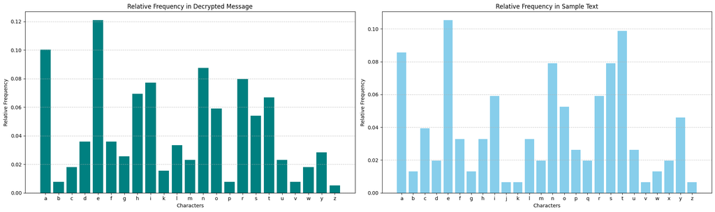

```python
import matplotlib.pyplot as plt
from collections import Counter
import pandas as pd

# Assuming 'decrypted_message' is available from previous steps

# Define the plot_relative_frequency function again for this cell's scope
def plot_relative_frequency(text, ax, title, color='skyblue'):
    """
    Calculates and plots the relative frequency of letters in a given text on a specified axes.

    Args:
        text (str): The input text to analyze.
        ax (matplotlib.axes.Axes): The axes object to plot on.
        title (str): The title for the plot.
        color (str): The color of the bars.
    """
    cleaned_text = ''.join(filter(str.isalpha, text.lower()))
    if not cleaned_text:
        print(f"Error: No alphabetic characters found in the text for {title}.")
        return

    char_counts = Counter(cleaned_text)
    total_chars = len(cleaned_text)
    relative_frequencies = {char: count / total_chars for char, count in char_counts.items()}

    sorted_freqs = sorted(relative_frequencies.items())
    chars, freqs = zip(*sorted_freqs)

    ax.bar(chars, freqs, color=color)
    ax.set_title(title)
    ax.set_xlabel('Characters')
    ax.set_ylabel('Relative Frequency')
    ax.grid(axis='y', linestyle='--', alpha=0.7)


# --- Sample Text (copied from previous cell for comparison) ---
sample_text = """
The quick brown fox jumps over the lazy dog.
This is an example text to demonstrate character frequency analysis.
Cryptanalysis often begins with frequency analysis to find patterns.
"""

if 'decrypted_message' in locals():
    fig, axes = plt.subplots(1, 2, figsize=(20, 6)) # Create a figure with 2 subplots

    # Plot for Decrypted Message
    plot_relative_frequency(decrypted_message, axes[0], 'Relative Frequency in Decrypted Message', color='teal')

    # Plot for Sample Text
    plot_relative_frequency(sample_text, axes[1], 'Relative Frequency in Sample Text', color='skyblue')

    plt.tight_layout() # Adjust layout to prevent overlap
    plt.show()

else:
    print("Decrypted message is not available for plotting.")
```